# **Facial Emotion Detection**

### **Evaluating the Model on the Test Set**

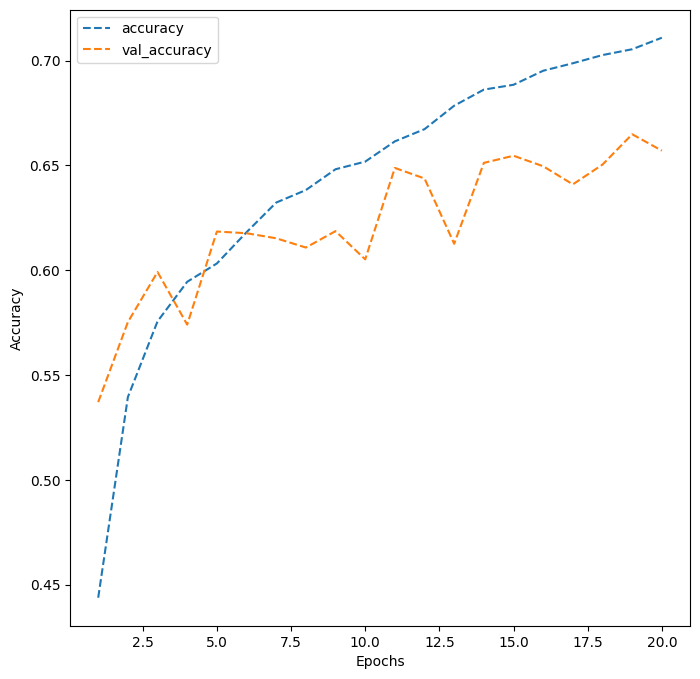

```python
dict_hist = history_cnn_model_1.history

list_ep = [i for i in range(1, 21)]
plt.figure(figsize = (8, 8))
plt.plot(list_ep, dict_hist['accuracy'], ls = '--', label = 'accuracy')
plt.plot(list_ep, dict_hist['val_accuracy'], ls = '--', label = 'val_accuracy')
plt.ylabel('Accuracy')
plt.xlabel('Epochs')
plt.legend()
plt.show()
```

```python
# Checking out the prediction on the test set
# Predict on the entire test set, specifying steps to cover all samples
test_pred = cnn_model_1.predict(test_set, steps=len(test_set))

# Get predicted class indices
y_pred = np.argmax(test_pred, axis=1)

# True labels from the generator
y_true = test_set.classes

print(classification_report(y_true, y_pred, target_names=list(test_set.class_indices.keys())))
```

```
4/4 ━━━━━━━━━━━━━━━━━━━━ 0s 23ms/step
              precision    recall  f1-score   support

       happy       0.31      0.28      0.30        32
     neutral       0.33      0.38      0.35        32
         sad       0.21      0.22      0.21        32
    surprise       0.24      0.22      0.23        32

    accuracy                           0.27       128
   macro avg       0.27      0.27      0.27       128
weighted avg       0.27      0.27      0.27       128
```

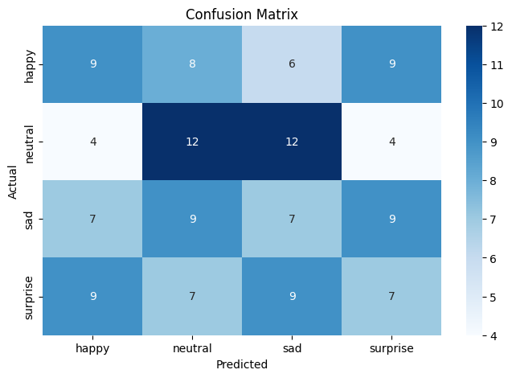

```python
# True labels from the generator
y_true = test_set.classes

# Compute confusion matrix
cm = confusion_matrix(y_true, y_pred)

# Plot confusion matrix
plt.figure(figsize=(8, 5))
sns.heatmap(cm, annot=True, fmt='.0f', cmap='Blues',
            xticklabels=list(test_set.class_indices.keys()),
            yticklabels=list(test_set.class_indices.keys()))
plt.ylabel('Actual')
plt.xlabel('Predicted')
plt.title('Confusion Matrix')
plt.show()
```

**Observations and Insights: The model performs decently, but the test set is so small, it really misclassifies most of it. Furthermore in the validation split it seems to underperform, which would mean we are looking at an overfitting problem. This is similar to the Elective proyect, so we should, now, add a dropout layer to prevent this**

### **Creating the second Convolutional Neural Network**

- Try out a slightly larger architecture

```python
# Clear previous session
backend.clear_session()
```

```python
# Set random seeds:
np.random.seed(42)
random.seed(42)
tf.random.set_seed(42)
```

```python
# Changing it to be rgb:
# We create an image data generator to balance and avoid overfitting the model, this will create new variations to existing images

batch_size = 32
img_size = 32 # Small image size due to computation limitations in google collab
folder_path = '/content/Facial_emotion_images/'


datagen_train = ImageDataGenerator(
    rotation_range=10,
    zoom_range=0.1,
    horizontal_flip=True,
    brightness_range=(0.5, 1),
    rescale=1/255
)
train_set = datagen_train.flow_from_directory(
    folder_path + "train",
    target_size=(img_size, img_size),
    color_mode='rgb',
    batch_size=batch_size,
    class_mode='categorical',
    shuffle=True
)

datagen_test= ImageDataGenerator(
    rotation_range=10,
    zoom_range=0.1,
    horizontal_flip=True,
    brightness_range=(0.5, 1),
    rescale=1/255
)


test_set = datagen_test.flow_from_directory(
    folder_path + "test",
    target_size=(img_size, img_size),
    color_mode='rgb',  # or 'rgb' depending on your images
    batch_size=batch_size,
    class_mode='categorical',
    shuffle=True
)

datagen_validation = ImageDataGenerator(
    rotation_range=10,
    zoom_range=0.1,
    horizontal_flip=True,
    brightness_range=(0.5, 1),
    rescale=1/255
)

validation_set = datagen_validation.flow_from_directory(
    folder_path + "validation",
    target_size=(img_size, img_size),
    color_mode='rgb',  # or 'rgb' depending on your images
    batch_size=batch_size,
    class_mode='categorical',
    shuffle=True
)
```

```
Found 15109 images belonging to 4 classes.
Found 128 images belonging to 4 classes.
Found 4977 images belonging to 4 classes.
```

```python
# Now we follow with a max polling section, adding dropout layers and normalizing the data, this is the same model used during the elective part
# In that case it heavily improved prediction, hopefully it will do the same now
from tensorflow.keras.layers import Conv2D, LeakyReLU, MaxPooling2D, Flatten


def cnn_model_2():
    model = Sequential()

    model.add(Conv2D(16, (3, 3), padding='same', input_shape=(32, 32, 3))) # changing the model so it takes RGB
    model.add(LeakyReLU(alpha=0.1))
    model.add(Conv2D(32, (3, 3), padding='same'))
    model.add(LeakyReLU(alpha=0.1))
    model.add(MaxPooling2D((2, 2)))
    # Early normalization to prevent drift
    model.add(BatchNormalization())
    model.add(Conv2D(32, (3, 3), padding='same'))
    model.add(LeakyReLU(alpha=0.1))
    model.add(Conv2D(64, (3, 3), padding='same'))
    model.add(LeakyReLU(alpha=0.1))
    model.add(MaxPooling2D((2, 2)))
    model.add(BatchNormalization())
    model.add(Flatten())
    model.add(Dense(32))
    model.add(LeakyReLU(alpha=0.1))
    # Missing dropout layer
    model.add(Dropout(0.5))
    model.add(Dense(4, activation='softmax'))

    model.compile(loss='categorical_crossentropy', optimizer=Adam(learning_rate=0.001), metrics=['accuracy'])

    return model

cnn_model_2 = cnn_model_2()
```

### **Compiling and Training the Model**

```python
cnn_model_2.summary()
```

```
Model: "sequential_2"
```

```
┏━━━━━━━━━━━━━━━━━━━━━━━━━━━━━━━━━┳━━━━━━━━━━━━━━━━━━━━━━━━┳━━━━━━━━━━━━━━━┓
┃ Layer (type)                    ┃ Output Shape           ┃       Param # ┃
┡━━━━━━━━━━━━━━━━━━━━━━━━━━━━━━━━━╇━━━━━━━━━━━━━━━━━━━━━━━━╇━━━━━━━━━━━━━━━┩
│ conv2d_8 (Conv2D)               │ (None, 32, 32, 16)     │           448 │
├─────────────────────────────────┼────────────────────────┼───────────────┤
│ leaky_re_lu_10 (LeakyReLU)      │ (None, 32, 32, 16)     │             0 │
├─────────────────────────────────┼────────────────────────┼───────────────┤
│ conv2d_9 (Conv2D)               │ (None, 32, 32, 32)     │         4,640 │
├─────────────────────────────────┼────────────────────────┼───────────────┤
│ leaky_re_lu_11 (LeakyReLU)      │ (None, 32, 32, 32)     │             0 │
├─────────────────────────────────┼────────────────────────┼───────────────┤
│ max_pooling2d_4 (MaxPooling2D)  │ (None, 16, 16, 32)     │             0 │
├─────────────────────────────────┼────────────────────────┼───────────────┤
│ batch_normalization_4           │ (None, 16, 16, 32)     │           128 │
│ (BatchNormalization)            │                        │               │
├─────────────────────────────────┼────────────────────────┼───────────────┤
│ conv2d_10 (Conv2D)              │ (None, 16, 16, 32)     │         9,248 │
├─────────────────────────────────┼────────────────────────┼───────────────┤
│ leaky_re_lu_12 (LeakyReLU)      │ (None, 16, 16, 32)     │             0 │
├─────────────────────────────────┼────────────────────────┼───────────────┤
│ conv2d_11 (Conv2D)              │ (None, 16, 16, 64)     │        18,496 │
├─────────────────────────────────┼────────────────────────┼───────────────┤
│ leaky_re_lu_13 (LeakyReLU)      │ (None, 16, 16, 64)     │             0 │
├─────────────────────────────────┼────────────────────────┼───────────────┤
│ max_pooling2d_5 (MaxPooling2D)  │ (None, 8, 8, 64)       │             0 │
├─────────────────────────────────┼────────────────────────┼───────────────┤
│ batch_normalization_5           │ (None, 8, 8, 64)       │           256 │
│ (BatchNormalization)            │                        │               │
├─────────────────────────────────┼────────────────────────┼───────────────┤
│ flatten_2 (Flatten)             │ (None, 4096)           │             0 │
├─────────────────────────────────┼────────────────────────┼───────────────┤
│ dense_4 (Dense)                 │ (None, 32)             │       131,104 │
├─────────────────────────────────┼────────────────────────┼───────────────┤
│ leaky_re_lu_14 (LeakyReLU)      │ (None, 32)             │             0 │
├─────────────────────────────────┼────────────────────────┼───────────────┤
│ dropout_2 (Dropout)             │ (None, 32)             │             0 │
├─────────────────────────────────┼────────────────────────┼───────────────┤
│ dense_5 (Dense)                 │ (None, 4)              │           132 │
└─────────────────────────────────┴────────────────────────┴───────────────┘
```

```
 Total params: 164,452 (642.39 KB)
```

```
 Trainable params: 164,260 (641.64 KB)
```

```
 Non-trainable params: 192 (768.00 B)
```

```python
history_cnn_model_2 = cnn_model_2.fit(train_set,epochs=20,validation_data=validation_set)
```

```
473/473 ━━━━━━━━━━━━━━━━━━━━ 29s 52ms/step - accuracy: 0.3552 - loss: 1.4865 - val_accuracy: 0.4163 - val_loss: 1.2264
473/473 ━━━━━━━━━━━━━━━━━━━━ 22s 46ms/step - accuracy: 0.4934 - loss: 1.1525 - val_accuracy: 0.4511 - val_loss: 1.2242
473/473 ━━━━━━━━━━━━━━━━━━━━ 21s 43ms/step - accuracy: 0.5448 - loss: 1.0406 - val_accuracy: 0.5867 - val_loss: 0.9801
473/473 ━━━━━━━━━━━━━━━━━━━━ 21s 45ms/step - accuracy: 0.5887 - loss: 0.9713 - val_accuracy: 0.6261 - val_loss: 0.8873
473/473 ━━━━━━━━━━━━━━━━━━━━ 21s 43ms/step - accuracy: 0.6010 - loss: 0.9266 - val_accuracy: 0.6468 - val_loss: 0.8768
473/473 ━━━━━━━━━━━━━━━━━━━━ 42s 45ms/step - accuracy: 0.6163 - loss: 0.8910 - val_accuracy: 0.6474 - val_loss: 0.8787
473/473 ━━━━━━━━━━━━━━━━━━━━ 21s 44ms/step - accuracy: 0.6296 - loss: 0.8766 - val_accuracy: 0.6285 - val_loss: 0.8981
473/473 ━━━━━━━━━━━━━━━━━━━━ 21s 45ms/step - accuracy: 0.6499 - loss: 0.8490 - val_accuracy: 0.5963 - val_loss: 0.9327
473/473 ━━━━━━━━━━━━━━━━━━━━ 20s 43ms/step - accuracy: 0.6448 - loss: 0.8488 - val_accuracy: 0.6538 - val_loss: 0.8731
473/473 ━━━━━━━━━━━━━━━━━━━━ 21s 45ms/step - accuracy: 0.6546 - loss: 0.8200 - val_accuracy: 0.6637 - val_loss: 0.8118
473/473 ━━━━━━━━━━━━━━━━━━━━ 21s 45ms/step - accuracy: 0.6581 - loss: 0.8047 - val_accuracy: 0.6783 - val_loss: 0.7994
473/473 ━━━━━━━━━━━━━━━━━━━━ 41s 45ms/step - accuracy: 0.6689 - loss: 0.7888 - val_accuracy: 0.6641 - val_loss: 0.8174
473/473 ━━━━━━━━━━━━━━━━━━━━ 20s 43ms/step - accuracy: 0.6740 - loss: 0.7935 - val_accuracy: 0.6825 - val_loss: 0.8173
473/473 ━━━━━━━━━━━━━━━━━━━━ 22s 47ms/step - accuracy: 0.6769 - loss: 0.7792 - val_accuracy: 0.6721 - val_loss: 0.8062
473/473 ━━━━━━━━━━━━━━━━━━━━ 21s 44ms/step - accuracy: 0.6760 - loss: 0.7786 - val_accuracy: 0.6759 - val_loss: 0.8300
473/473 ━━━━━━━━━━━━━━━━━━━━ 41s 46ms/step - accuracy: 0.6752 - loss: 0.7823 - val_accuracy: 0.6791 - val_loss: 0.7919
473/473 ━━━━━━━━━━━━━━━━━━━━ 21s 44ms/step - accuracy: 0.6926 - loss: 0.7454 - val_accuracy: 0.6984 - val_loss: 0.7505
473/473 ━━━━━━━━━━━━━━━━━━━━ 42s 46ms/step - accuracy: 0.6872 - loss: 0.7581 - val_accuracy: 0.6918 - val_loss: 0.7727
473/473 ━━━━━━━━━━━━━━━━━━━━ 21s 44ms/step - accuracy: 0.6885 - loss: 0.7331 - val_accuracy: 0.6769 - val_loss: 0.7804
473/473 ━━━━━━━━━━━━━━━━━━━━ 22s 47ms/step - accuracy: 0.6893 - loss: 0.7321 - val_accuracy: 0.6837 - val_loss: 0.7837
```

### **Evaluating the Model on the Test Set**

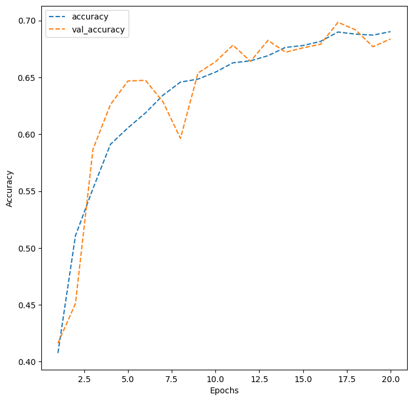

```python
# Plotting the accuracies

dict_hist = history_cnn_model_2.history

list_ep = [i for i in range(1, 21)]
plt.figure(figsize = (8, 8))
plt.plot(list_ep, dict_hist['accuracy'], ls = '--', label = 'accuracy')
plt.plot(list_ep, dict_hist['val_accuracy'], ls = '--', label = 'val_accuracy')
plt.ylabel('Accuracy')
plt.xlabel('Epochs')
plt.legend()
plt.show()
```

```python
# Checking out the prediction on the test set
# Predict on the entire test set, specifying steps to cover all samples
test_pred = cnn_model_2.predict(test_set, steps=len(test_set))

# Get predicted class indices
y_pred = np.argmax(test_pred, axis=1)

# True labels from the generator
y_true = test_set.classes

print(classification_report(y_true, y_pred, target_names=list(test_set.class_indices.keys())))
```

```
4/4 ━━━━━━━━━━━━━━━━━━━━ 1s 24ms/step
              precision    recall  f1-score   support

       happy       0.25      0.22      0.23        32
     neutral       0.19      0.28      0.23        32
         sad       0.29      0.22      0.25        32
    surprise       0.21      0.19      0.20        32

    accuracy                           0.23       128
   macro avg       0.24      0.23      0.23       128
weighted avg       0.24      0.23      0.23       128
```

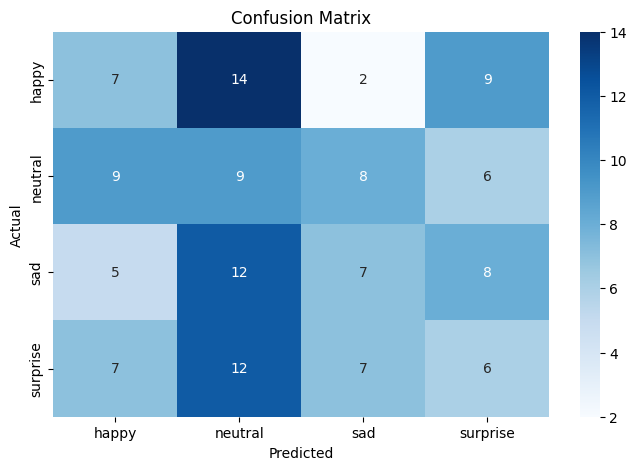

```python
# True labels from the generator
y_true = test_set.classes

# Compute confusion matrix
cm = confusion_matrix(y_true, y_pred)

# Plot confusion matrix
plt.figure(figsize=(8, 5))
sns.heatmap(cm, annot=True, fmt='.0f', cmap='Blues',
            xticklabels=list(test_set.class_indices.keys()),
            yticklabels=list(test_set.class_indices.keys()))
plt.ylabel('Actual')
plt.xlabel('Predicted')
plt.title('Confusion Matrix')
plt.show()
```

**Observations and Insights: It is incredible how these models do with the test set. The test set is it is so small and it is still not accurate at all. Even though this model seemingly helped with the overfitting, with 20 epochs 70% accuracy is way worse than that of the model categorizing numbers. Being less clearcut differences in facial expression it is to be expected, but it is still nowhere near good enough. Furthermore it seems RGB did not add any significant improvements to the classification**

## **Think About It:**

- Did the models have a satisfactory performance? If not, then what are the possible reasons?

They did not, it seems that there are several problems with classification such that the final test set preditions are not good at all. I believe it is because the images are very simmilar between one and other, maybe the resolution is not helping.

- Which Color mode showed better overall performance? What are the possible reasons? Do you think having 'rgb' color mode is needed because the images are already black and white?

It did not help at all. I believe it is because feautures in facial expressions are not dependent on color, and the contrast does not do much in order to separate clearly between said classes. The images originaly being BnW do probably test affect this.

## **Transfer Learning Architectures**

In this section, we will create several Transfer Learning architectures. For the pre-trained models, we will select three popular architectures namely, VGG16, ResNet v2, and Efficient Net. The difference between these architectures and the previous architectures is that these will require 3 input channels while the earlier ones worked on 'grayscale' images. Therefore, we need to create new DataLoaders.

### **Creating our Data Loaders for Transfer Learning Architectures**

In this section, we are creating data loaders that we will use as inputs to our Neural Network. We will have to go with color_mode = 'rgb' as this is the required format for the transfer learning architectures.

```python
# Clear previous session
backend.clear_session()
```

```python
# Set random seeds:
np.random.seed(42)
random.seed(42)
tf.random.set_seed(42)
```

```python
# Same as before

# Changing it to be rgb:
# We create an image data generator to balance and avoid overfitting the model, this will create new variations to existing images

batch_size = 32
img_size = 48 # Make the image bigger maybe will help, plus the AI said it was a requirement for AVGG16
folder_path = '/content/Facial_emotion_images/'


datagen_train = ImageDataGenerator(
    rotation_range=10,
    zoom_range=0.1,
    horizontal_flip=True,
    brightness_range=(0.5, 1),
    rescale=1/255
)
train_set = datagen_train.flow_from_directory(
    folder_path + "train",
    target_size=(img_size, img_size),
    color_mode='rgb',
    batch_size=batch_size,
    class_mode='categorical',
    shuffle=True
)

datagen_test= ImageDataGenerator(
    rotation_range=10,
    zoom_range=0.1,
    horizontal_flip=True,
    brightness_range=(0.5, 1),
    rescale=1/255
)


test_set = datagen_test.flow_from_directory(
    folder_path + "test",
    target_size=(img_size, img_size),
    color_mode='rgb',  # or 'rgb' depending on your images
    batch_size=batch_size,
    class_mode='categorical',
    shuffle=True
)

datagen_validation = ImageDataGenerator(
    rotation_range=10,
    zoom_range=0.1,
    horizontal_flip=True,
    brightness_range=(0.5, 1),
    rescale=1/255
)

validation_set = datagen_validation.flow_from_directory(
    folder_path + "validation",
    target_size=(img_size, img_size),
    color_mode='rgb',  # or 'rgb' depending on your images
    batch_size=batch_size,
    class_mode='categorical',
    shuffle=True
)
```

```
Found 15109 images belonging to 4 classes.
Found 128 images belonging to 4 classes.
Found 4977 images belonging to 4 classes.
```

## **VGG16 Model**

### **Importing the VGG16 Architecture**

```python
# This is a pretrained model

from tensorflow.keras.applications.vgg16 import VGG16
from tensorflow.keras import Model

vgg_base = VGG16(weights='imagenet', include_top=False, input_shape=(48, 48, 3))
vgg.summary()
vgg_base.trainable = False  # freeze the base for now (fine-tune later if needed)
```

```
Model: "vgg16"
```

```
┏━━━━━━━━━━━━━━━━━━━━━━━━━━━━━━━━━┳━━━━━━━━━━━━━━━━━━━━━━━━┳━━━━━━━━━━━━━━━┓
┃ Layer (type)                    ┃ Output Shape           ┃       Param # ┃
┡━━━━━━━━━━━━━━━━━━━━━━━━━━━━━━━━━╇━━━━━━━━━━━━━━━━━━━━━━━━╇━━━━━━━━━━━━━━━┩
│ input_layer_1 (InputLayer)      │ (None, 48, 48, 3)      │             0 │
├─────────────────────────────────┼────────────────────────┼───────────────┤
│ block1_conv1 (Conv2D)           │ (None, 48, 48, 64)     │         1,792 │
├─────────────────────────────────┼────────────────────────┼───────────────┤
│ block1_conv2 (Conv2D)           │ (None, 48, 48, 64)     │        36,928 │
├─────────────────────────────────┼────────────────────────┼───────────────┤
│ block1_pool (MaxPooling2D)      │ (None, 24, 24, 64)     │             0 │
├─────────────────────────────────┼────────────────────────┼───────────────┤
│ block2_conv1 (Conv2D)           │ (None, 24, 24, 128)    │        73,856 │
├─────────────────────────────────┼────────────────────────┼───────────────┤
│ block2_conv2 (Conv2D)           │ (None, 24, 24, 128)    │       147,584 │
├─────────────────────────────────┼────────────────────────┼───────────────┤
│ block2_pool (MaxPooling2D)      │ (None, 12, 12, 128)    │             0 │
├─────────────────────────────────┼────────────────────────┼───────────────┤
│ block3_conv1 (Conv2D)           │ (None, 12, 12, 256)    │       295,168 │
├─────────────────────────────────┼────────────────────────┼───────────────┤
│ block3_conv2 (Conv2D)           │ (None, 12, 12, 256)    │       590,080 │
├─────────────────────────────────┼────────────────────────┼───────────────┤
│ block3_conv3 (Conv2D)           │ (None, 12, 12, 256)    │       590,080 │
├─────────────────────────────────┼────────────────────────┼───────────────┤
│ block3_pool (MaxPooling2D)      │ (None, 6, 6, 256)      │             0 │
├─────────────────────────────────┼────────────────────────┼───────────────┤
│ block4_conv1 (Conv2D)           │ (None, 6, 6, 512)      │     1,180,160 │
├─────────────────────────────────┼────────────────────────┼───────────────┤
│ block4_conv2 (Conv2D)           │ (None, 6, 6, 512)      │     2,359,808 │
├─────────────────────────────────┼────────────────────────┼───────────────┤
│ block4_conv3 (Conv2D)           │ (None, 6, 6, 512)      │     2,359,808 │
├─────────────────────────────────┼────────────────────────┼───────────────┤
│ block4_pool (MaxPooling2D)      │ (None, 3, 3, 512)      │             0 │
├─────────────────────────────────┼────────────────────────┼───────────────┤
│ block5_conv1 (Conv2D)           │ (None, 3, 3, 512)      │     2,359,808 │
├─────────────────────────────────┼────────────────────────┼───────────────┤
│ block5_conv2 (Conv2D)           │ (None, 3, 3, 512)      │     2,359,808 │
├─────────────────────────────────┼────────────────────────┼───────────────┤
│ block5_conv3 (Conv2D)           │ (None, 3, 3, 512)      │     2,359,808 │
├─────────────────────────────────┼────────────────────────┼───────────────┤
│ block5_pool (MaxPooling2D)      │ (None, 1, 1, 512)      │             0 │
└─────────────────────────────────┴────────────────────────┴───────────────┘
```

```
 Total params: 14,714,688 (56.13 MB)
```

```
 Trainable params: 14,714,688 (56.13 MB)
```

```
 Non-trainable params: 0 (0.00 B)
```

### **Model Building**

- Import VGG16 upto the layer of your choice and add Fully Connected layers on top of it.

```python
from tensorflow.keras.layers import GlobalAveragePooling2D, Dense

# Load the VGG16 base (exclude top classifier, use pretrained weights)
vgg_model = Sequential([
    vgg_base,
    GlobalAveragePooling2D(), # Adding some layers on top of it
    Dense(64, activation='relu'),
    Dense(train_set.num_classes, activation='softmax') # final output layer with 4 categories
])

vgg_model.compile(optimizer=Adam(learning_rate=0.01),
              loss='categorical_crossentropy',
              metrics=['accuracy'])
```

### **Compiling and Training the VGG16 Model**

```python
vgg_history = vgg_model.fit(train_set,validation_data=validation_set,epochs=10)
```

```
473/473 ━━━━━━━━━━━━━━━━━━━━ 35s 71ms/step - accuracy: 0.4212 - loss: 1.2514 - val_accuracy: 0.4812 - val_loss: 1.1609
473/473 ━━━━━━━━━━━━━━━━━━━━ 33s 71ms/step - accuracy: 0.4897 - loss: 1.1531 - val_accuracy: 0.4720 - val_loss: 1.1652
473/473 ━━━━━━━━━━━━━━━━━━━━ 30s 63ms/step - accuracy: 0.5068 - loss: 1.1282 - val_accuracy: 0.4710 - val_loss: 1.1822
473/473 ━━━━━━━━━━━━━━━━━━━━ 30s 63ms/step - accuracy: 0.5143 - loss: 1.1072 - val_accuracy: 0.4780 - val_loss: 1.1815
473/473 ━━━━━━━━━━━━━━━━━━━━ 30s 64ms/step - accuracy: 0.5119 - loss: 1.1180 - val_accuracy: 0.4868 - val_loss: 1.1536
473/473 ━━━━━━━━━━━━━━━━━━━━ 41s 65ms/step - accuracy: 0.5137 - loss: 1.1025 - val_accuracy: 0.5087 - val_loss: 1.1366
473/473 ━━━━━━━━━━━━━━━━━━━━ 41s 65ms/step - accuracy: 0.5142 - loss: 1.0951 - val_accuracy: 0.5118 - val_loss: 1.1227
473/473 ━━━━━━━━━━━━━━━━━━━━ 30s 63ms/step - accuracy: 0.5193 - loss: 1.1007 - val_accuracy: 0.5218 - val_loss: 1.1191
473/473 ━━━━━━━━━━━━━━━━━━━━ 34s 71ms/step - accuracy: 0.5158 - loss: 1.0970 - val_accuracy: 0.5226 - val_loss: 1.0978
473/473 ━━━━━━━━━━━━━━━━━━━━ 37s 64ms/step - accuracy: 0.5108 - loss: 1.1031 - val_accuracy: 0.4420 - val_loss: 1.2374
```

### **Evaluating the VGG16 model**

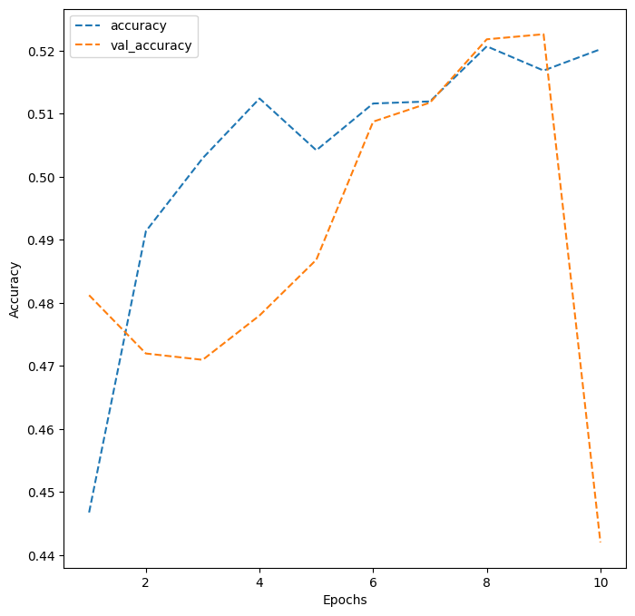

```python
# Plotting the accuracies

dict_hist = vgg_history.history

list_ep = [i for i in range(1, 11)]
plt.figure(figsize = (8, 8))
plt.plot(list_ep, dict_hist['accuracy'], ls = '--', label = 'accuracy')
plt.plot(list_ep, dict_hist['val_accuracy'], ls = '--', label = 'val_accuracy')
plt.ylabel('Accuracy')
plt.xlabel('Epochs')
plt.legend()
plt.show()
```

**Think About It:**

- What do you infer from the general trend in the training performance?

The fact is that using a pretrained architecture built on 244 images in RGB is not helping my classification problem. The architecture is much heavier and it takes a long time to parse out the images. Furthermore it is less accurate than before. Perhaps Loading images in 244 would help, this was suggested by the AI, but it is not feasible using google collab.

- Is the training accuracy consistently improving?

No, the previous CNN did better, but between epochs yes, it is improving.

- Is the validation accuracy also improving similarly?

It dropped dramatically in the last epoch, i am not sure why this is

**Observations and Insights: It is hard to adapt a previous network, it is necessary to find a network which has been trained to help specifically the dataset I am using. **

**Note: You can even go back and build your own architecture on top of the VGG16 Transfer layer and see if you can improve the performance**

## **ResNet V2 Model**

```python
# Clear previous session
backend.clear_session()

# Set random seeds:
np.random.seed(42)
random.seed(42)
tf.random.set_seed(42)
```

### **Model Building**

- Import Resnet v2 upto the layer of your choice and add Fully Connected layers on top of it.

```python
from tensorflow.keras.applications import ResNet50V2
```

### **Compiling and Training the Model**

```python
img_size = 48
batch_size = 32

datagen = ImageDataGenerator(rescale=1./255) # Simpler data generator

train_set = datagen.flow_from_directory(
    folder_path + "train",
    target_size=(img_size, img_size),
    color_mode='rgb',
    batch_size=batch_size,
    class_mode='categorical',
    shuffle=True
)

validation_set = datagen.flow_from_directory(
    folder_path + "validation",
    target_size=(img_size, img_size),
    color_mode='rgb',
    batch_size=batch_size,
    class_mode='categorical',
    shuffle=True
)

test_set = datagen.flow_from_directory(
    folder_path + "test",
    target_size=(img_size, img_size),
    color_mode='rgb',
    batch_size=batch_size,
    class_mode='categorical',
    shuffle=False
)
```

```
Found 15109 images belonging to 4 classes.
Found 4977 images belonging to 4 classes.
Found 128 images belonging to 4 classes.
```

```python
resnet_base = ResNet50V2(weights=None, # Removing pretrained weights!
                         include_top=False, input_shape=(48, 48, 3))

resnet_model = Sequential([
    resnet_base,
    GlobalAveragePooling2D(), # Needed to flatten the layer
    Dense(64, activation='relu'),
    Dense(train_set.num_classes, activation='softmax') # Add final output layer
])

resnet_model.compile(
    optimizer=Adam(learning_rate=0.001),
    loss='categorical_crossentropy',
    metrics=['accuracy']
)
```

```python
# Incredibly complex
resnet_base.summary()
```

```
Model: "resnet50v2"
```

```
┏━━━━━━━━━━━━━━━━━━━━━┳━━━━━━━━━━━━━━━━━━━┳━━━━━━━━━━━━┳━━━━━━━━━━━━━━━━━━━┓
┃ Layer (type)        ┃ Output Shape      ┃    Param # ┃ Connected to      ┃
┡━━━━━━━━━━━━━━━━━━━━━╇━━━━━━━━━━━━━━━━━━━╇━━━━━━━━━━━━╇━━━━━━━━━━━━━━━━━━━┩
│ input_layer_6       │ (None, 48, 48, 3) │          0 │ -                 │
│ (InputLayer)        │                   │            │                   │
├─────────────────────┼───────────────────┼────────────┼───────────────────┤
│ conv1_pad           │ (None, 54, 54, 3) │          0 │ input_layer_6[0]… │
│ (ZeroPadding2D)     │                   │            │                   │
├─────────────────────┼───────────────────┼────────────┼───────────────────┤
│ conv1_conv (Conv2D) │ (None, 24, 24,    │      9,472 │ conv1_pad[0][0]   │
│                     │ 64)               │            │                   │
├─────────────────────┼───────────────────┼────────────┼───────────────────┤
│ pool1_pad           │ (None, 26, 26,    │          0 │ conv1_conv[0][0]  │
│ (ZeroPadding2D)     │ 64)               │            │                   │
├─────────────────────┼───────────────────┼────────────┼───────────────────┤
│ pool1_pool          │ (None, 12, 12,    │          0 │ pool1_pad[0][0]   │
│ (MaxPooling2D)      │ 64)               │            │                   │
├─────────────────────┼───────────────────┼────────────┼───────────────────┤
│ conv2_block1_preac… │ (None, 12, 12,    │        256 │ pool1_pool[0][0]  │
│ (BatchNormalizatio… │ 64)               │            │                   │
├─────────────────────┼───────────────────┼────────────┼───────────────────┤
│ conv2_block1_preac… │ (None, 12, 12,    │          0 │ conv2_block1_pre… │
│ (Activation)        │ 64)               │            │                   │
├─────────────────────┼───────────────────┼────────────┼───────────────────┤
│ conv2_block1_1_conv │ (None, 12, 12,    │      4,096 │ conv2_block1_pre… │
│ (Conv2D)            │ 64)               │            │                   │
├─────────────────────┼───────────────────┼────────────┼───────────────────┤
│ conv2_block1_1_bn   │ (None, 12, 12,    │        256 │ conv2_block1_1_c… │
│ (BatchNormalizatio… │ 64)               │            │                   │
├─────────────────────┼───────────────────┼────────────┼───────────────────┤
│ conv2_block1_1_relu │ (None, 12, 12,    │          0 │ conv2_block1_1_b… │
│ (Activation)        │ 64)               │            │                   │
├─────────────────────┼───────────────────┼────────────┼───────────────────┤
│ conv2_block1_2_pad  │ (None, 14, 14,    │          0 │ conv2_block1_1_r… │
│ (ZeroPadding2D)     │ 64)               │            │                   │
├─────────────────────┼───────────────────┼────────────┼───────────────────┤
│ conv2_block1_2_conv │ (None, 12, 12,    │     36,864 │ conv2_block1_2_p… │
│ (Conv2D)            │ 64)               │            │                   │
├─────────────────────┼───────────────────┼────────────┼───────────────────┤
│ conv2_block1_2_bn   │ (None, 12, 12,    │        256 │ conv2_block1_2_c… │
```

[output cut: 518 more lines]

```
│ conv5_block3_2_relu │ (None, 2, 2, 512) │          0 │ conv5_block3_2_b… │
│ (Activation)        │                   │            │                   │
├─────────────────────┼───────────────────┼────────────┼───────────────────┤
│ conv5_block3_3_conv │ (None, 2, 2,      │  1,050,624 │ conv5_block3_2_r… │
│ (Conv2D)            │ 2048)             │            │                   │
├─────────────────────┼───────────────────┼────────────┼───────────────────┤
│ conv5_block3_out    │ (None, 2, 2,      │          0 │ conv5_block2_out… │
│ (Add)               │ 2048)             │            │ conv5_block3_3_c… │
├─────────────────────┼───────────────────┼────────────┼───────────────────┤
│ post_bn             │ (None, 2, 2,      │      8,192 │ conv5_block3_out… │
│ (BatchNormalizatio… │ 2048)             │            │                   │
├─────────────────────┼───────────────────┼────────────┼───────────────────┤
│ post_relu           │ (None, 2, 2,      │          0 │ post_bn[0][0]     │
│ (Activation)        │ 2048)             │            │                   │
└─────────────────────┴───────────────────┴────────────┴───────────────────┘
```

```
 Total params: 23,564,800 (89.89 MB)
```

```
 Trainable params: 23,519,360 (89.72 MB)
```

```
 Non-trainable params: 45,440 (177.50 KB)
```

```python
resnet_history = resnet_model.fit(
    train_set,
    validation_data=validation_set,
    epochs=10  # adjust based on performance and overfitting
)
```

```
473/473 ━━━━━━━━━━━━━━━━━━━━ 138s 105ms/step - accuracy: 0.2806 - loss: 1.4264 - val_accuracy: 0.3667 - val_loss: 1.3716
473/473 ━━━━━━━━━━━━━━━━━━━━ 24s 51ms/step - accuracy: 0.2678 - loss: 1.3759 - val_accuracy: 0.3014 - val_loss: 1.3326
473/473 ━━━━━━━━━━━━━━━━━━━━ 22s 46ms/step - accuracy: 0.3793 - loss: 1.2437 - val_accuracy: 0.3944 - val_loss: 1.3052
473/473 ━━━━━━━━━━━━━━━━━━━━ 22s 46ms/step - accuracy: 0.3931 - loss: 1.1715 - val_accuracy: 0.4354 - val_loss: 1.2293
473/473 ━━━━━━━━━━━━━━━━━━━━ 22s 46ms/step - accuracy: 0.4100 - loss: 1.1332 - val_accuracy: 0.3179 - val_loss: 1.1975
473/473 ━━━━━━━━━━━━━━━━━━━━ 21s 45ms/step - accuracy: 0.4118 - loss: 1.1081 - val_accuracy: 0.3207 - val_loss: 1.1915
473/473 ━━━━━━━━━━━━━━━━━━━━ 22s 46ms/step - accuracy: 0.4216 - loss: 1.0808 - val_accuracy: 0.3607 - val_loss: 1.1475
473/473 ━━━━━━━━━━━━━━━━━━━━ 24s 52ms/step - accuracy: 0.4295 - loss: 1.0788 - val_accuracy: 0.3424 - val_loss: 1.3374
473/473 ━━━━━━━━━━━━━━━━━━━━ 23s 49ms/step - accuracy: 0.4365 - loss: 1.0578 - val_accuracy: 0.3369 - val_loss: 1.1812
473/473 ━━━━━━━━━━━━━━━━━━━━ 40s 47ms/step - accuracy: 0.4430 - loss: 1.0365 - val_accuracy: 0.3347 - val_loss: 1.4538
```

### **Evaluating the ResNet Model**

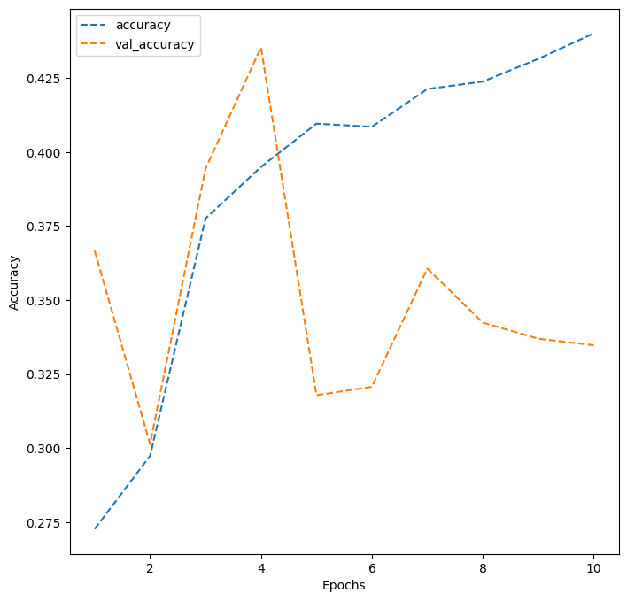

```python
# Plotting the accuracies

dict_hist = resnet_history.history

list_ep = [i for i in range(1, 11)]
plt.figure(figsize = (8, 8))
plt.plot(list_ep, dict_hist['accuracy'], ls = '--', label = 'accuracy')
plt.plot(list_ep, dict_hist['val_accuracy'], ls = '--', label = 'val_accuracy')
plt.ylabel('Accuracy')
plt.xlabel('Epochs')
plt.legend()
plt.show()
```

**Observations and Insights: This has been the worst performing model so far. It really speaks to the need to accuratly fit a model to an architecture which is saavily constructed. The AI told me to drop the weights and I did, which means this complex architecture is only built on the loaded train data, which tells us that the complexity of a NN is not always indicative of it's best predictions. **

**Note: You can even go back and build your own architecture on top of the ResNet Transfer layer and see if you can improve the performance.**

## **EfficientNet Model**

```python
# Clear previous session
backend.clear_session()

# Set random seeds:
np.random.seed(42)
random.seed(42)
tf.random.set_seed(42)
```

### **Model Building**

- Import EfficientNet upto the layer of your choice and add Fully Connected layers on top of it.

```python
from tensorflow.keras.applications import EfficientNetB0

base_model = EfficientNetB0(
    include_top=False,        # exclude final classification layer
    weights='imagenet',       # load pretrained ImageNet weights
    input_shape=(img_size, img_size, 3))
```

```
Downloading data from https://storage.googleapis.com/keras-applications/efficientnetb0_notop.h5
16705208/16705208 ━━━━━━━━━━━━━━━━━━━━ 2s 0us/step
```

```python
effi_model = Sequential([
    base_model,
    GlobalAveragePooling2D(),
    Dense(64, activation='relu'),
    Dense(train_set.num_classes, activation='softmax')
])

effi_model.summary()
```

```
Model: "sequential_1"
```

```
┏━━━━━━━━━━━━━━━━━━━━━━━━━━━━━━━━━┳━━━━━━━━━━━━━━━━━━━━━━━━┳━━━━━━━━━━━━━━━┓
┃ Layer (type)                    ┃ Output Shape           ┃       Param # ┃
┡━━━━━━━━━━━━━━━━━━━━━━━━━━━━━━━━━╇━━━━━━━━━━━━━━━━━━━━━━━━╇━━━━━━━━━━━━━━━┩
│ efficientnetb0 (Functional)     │ (None, 2, 2, 1280)     │     4,049,571 │
├─────────────────────────────────┼────────────────────────┼───────────────┤
│ global_average_pooling2d_1      │ (None, 1280)           │             0 │
│ (GlobalAveragePooling2D)        │                        │               │
├─────────────────────────────────┼────────────────────────┼───────────────┤
│ dense_2 (Dense)                 │ (None, 64)             │        81,984 │
├─────────────────────────────────┼────────────────────────┼───────────────┤
│ dense_3 (Dense)                 │ (None, 4)              │           260 │
└─────────────────────────────────┴────────────────────────┴───────────────┘
```

```
 Total params: 4,131,815 (15.76 MB)
```

```
 Trainable params: 4,089,792 (15.60 MB)
```

```
 Non-trainable params: 42,023 (164.16 KB)
```

### **Compiling and Training the Model**

```python
effi_model.compile(
    optimizer=Adam(learning_rate=0.001),
    loss='categorical_crossentropy',
    metrics=['accuracy']
)
```

```python
effi_history = effi_model.fit(
    train_set,
    validation_data=validation_set,
    epochs=20)
```

```
473/473 ━━━━━━━━━━━━━━━━━━━━ 132s 122ms/step - accuracy: 0.4728 - loss: 1.1990 - val_accuracy: 0.1802 - val_loss: 1.6390
473/473 ━━━━━━━━━━━━━━━━━━━━ 14s 30ms/step - accuracy: 0.6589 - loss: 0.8417 - val_accuracy: 0.1601 - val_loss: 2.3793
473/473 ━━━━━━━━━━━━━━━━━━━━ 14s 29ms/step - accuracy: 0.7064 - loss: 0.7363 - val_accuracy: 0.1609 - val_loss: 2.3243
473/473 ━━━━━━━━━━━━━━━━━━━━ 15s 31ms/step - accuracy: 0.7473 - loss: 0.6393 - val_accuracy: 0.2819 - val_loss: 1.8619
473/473 ━━━━━━━━━━━━━━━━━━━━ 20s 30ms/step - accuracy: 0.7749 - loss: 0.5753 - val_accuracy: 0.2708 - val_loss: 1.4778
473/473 ━━━━━━━━━━━━━━━━━━━━ 14s 30ms/step - accuracy: 0.7973 - loss: 0.5202 - val_accuracy: 0.2433 - val_loss: 3.6640
473/473 ━━━━━━━━━━━━━━━━━━━━ 20s 30ms/step - accuracy: 0.8144 - loss: 0.4828 - val_accuracy: 0.1605 - val_loss: 1.9728
473/473 ━━━━━━━━━━━━━━━━━━━━ 14s 29ms/step - accuracy: 0.8368 - loss: 0.4245 - val_accuracy: 0.2481 - val_loss: 2.0840
473/473 ━━━━━━━━━━━━━━━━━━━━ 15s 31ms/step - accuracy: 0.8736 - loss: 0.3386 - val_accuracy: 0.2407 - val_loss: 2.4235
473/473 ━━━━━━━━━━━━━━━━━━━━ 14s 30ms/step - accuracy: 0.8886 - loss: 0.2969 - val_accuracy: 0.2823 - val_loss: 3.7483
473/473 ━━━━━━━━━━━━━━━━━━━━ 23s 36ms/step - accuracy: 0.9099 - loss: 0.2560 - val_accuracy: 0.2280 - val_loss: 3.2763
473/473 ━━━━━━━━━━━━━━━━━━━━ 14s 30ms/step - accuracy: 0.9187 - loss: 0.2267 - val_accuracy: 0.2556 - val_loss: 2.7992
473/473 ━━━━━━━━━━━━━━━━━━━━ 14s 30ms/step - accuracy: 0.9337 - loss: 0.1812 - val_accuracy: 0.2293 - val_loss: 314.0741
473/473 ━━━━━━━━━━━━━━━━━━━━ 15s 31ms/step - accuracy: 0.9408 - loss: 0.1640 - val_accuracy: 0.2285 - val_loss: 59.5569
473/473 ━━━━━━━━━━━━━━━━━━━━ 14s 30ms/step - accuracy: 0.9339 - loss: 0.1914 - val_accuracy: 0.1609 - val_loss: 2.6450
473/473 ━━━━━━━━━━━━━━━━━━━━ 14s 30ms/step - accuracy: 0.9558 - loss: 0.1238 - val_accuracy: 0.3102 - val_loss: 3.8444
473/473 ━━━━━━━━━━━━━━━━━━━━ 14s 30ms/step - accuracy: 0.9563 - loss: 0.1258 - val_accuracy: 0.2172 - val_loss: 222.5263
473/473 ━━━━━━━━━━━━━━━━━━━━ 14s 29ms/step - accuracy: 0.9527 - loss: 0.1300 - val_accuracy: 0.2582 - val_loss: 3.9926
473/473 ━━━━━━━━━━━━━━━━━━━━ 15s 31ms/step - accuracy: 0.9615 - loss: 0.1078 - val_accuracy: 0.1459 - val_loss: 3.7268
473/473 ━━━━━━━━━━━━━━━━━━━━ 14s 30ms/step - accuracy: 0.9589 - loss: 0.1212 - val_accuracy: 0.2499 - val_loss: 3.2402
```

### **Evaluating the EfficientnetNet Model**

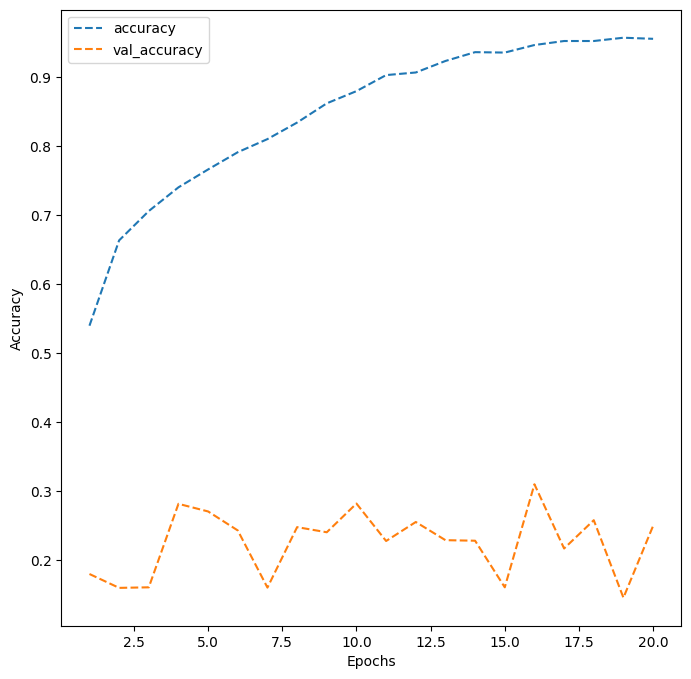

```python
# Plotting the accuracies

dict_hist = effi_history.history

list_ep = [i for i in range(1, 21)]
plt.figure(figsize = (8, 8))
plt.plot(list_ep, dict_hist['accuracy'], ls = '--', label = 'accuracy')
plt.plot(list_ep, dict_hist['val_accuracy'], ls = '--', label = 'val_accuracy')
plt.ylabel('Accuracy')
plt.xlabel('Epochs')
plt.legend()
plt.show()
```

**Observations and Insights:This model desperately need a dropout layer, it is incredibly overfit to the data, I can add one in the final submission but it seems to do very good in the training and not in the validation set. **

**Note: You can even go back and build your own architecture on top of the VGG16 Transfer layer and see if you can improve the performance.**

**Think About It:**

- What is your overall performance of these Transfer Learning Architectures? Can we draw a comparison of these models' performances. Are we satisfied with the accuracies that we have received?

Except for the last model which was really good with the fitting of the trainning data, all of the models performed worst than the base CNNs we build from scratch. The last one being incredibly overfit to the data.

This has to do with the images that trained them being color and higher resolution for sure, I'd need to study deeply these models and add several layers to improve their performance. Specially the last one, adding dropout layers inbetween it to help it.

- Do you think our issue lies with 'rgb' color_mode?

Definitely. This adds unnecessary complexity to images which are natively in BNW.

Now that we have tried multiple pre-trained models, let's build a complex CNN architecture and see if we can get better performance.

## **Creating our Data Loaders**

In this section, we are creating data loaders which we will use as inputs to the more Complicated Convolutional Neural Network. We will go ahead with color_mode = 'grayscale'.

```python
# Clear previous session
backend.clear_session()

# Set random seeds:
np.random.seed(420)
random.seed(420)
tf.random.set_seed(420)
```

```python
# We create an image data generator to balance and avoid overfitting the model, this will create new variations to existing images
batch_size = 32
img_size = 48
folder_path = '/content/Facial_emotion_images/'


datagen_train = ImageDataGenerator(
    rotation_range=10,
    zoom_range=0.1,
    horizontal_flip=True,
    brightness_range=(0.5, 1),
    rescale=1/255
)


train_set = datagen_train.flow_from_directory(
    folder_path + "train",
    target_size=(img_size, img_size),
    color_mode='grayscale',  # change from 'rgb'
    batch_size=batch_size,
    class_mode='categorical',
    shuffle=True
)


test_set = datagen_test.flow_from_directory(
    folder_path + "test",
    target_size=(img_size, img_size),
    color_mode='grayscale',
    batch_size=batch_size,
    class_mode='categorical',
    shuffle=True
)

validation_set = datagen_validation.flow_from_directory(
    folder_path + "validation",
    target_size=(img_size, img_size),
    color_mode='grayscale',
    batch_size=batch_size,
    class_mode='categorical',
    shuffle=True
)
```

```
Found 15109 images belonging to 4 classes.
Found 128 images belonging to 4 classes.
Found 4977 images belonging to 4 classes.
```

### **Model Building**

- Try building a layer with 5 Convolutional Blocks and see if performance increases.

```python
# Using the modell suggested in the Reference from the Low Code Option:

from tensorflow.keras.models import Sequential
from tensorflow.keras.layers import Conv2D, BatchNormalization, LeakyReLU, MaxPooling2D, Dropout
from tensorflow.keras.layers import Flatten, Dense, Activation
from tensorflow.keras.optimizers import Adam

# Build the CNN model
def build_custom_cnn(input_shape=(48, 48, 1), num_classes=4):
    model = Sequential()

    # Block 1
    model.add(Conv2D(64, (2, 2), padding='same', activation='relu', input_shape=input_shape))
    model.add(BatchNormalization())
    model.add(LeakyReLU(alpha=0.1))
    model.add(MaxPooling2D(pool_size=(2, 2)))
    model.add(Dropout(0.2))

    # Block 2
    model.add(Conv2D(128, (2, 2), padding='same', activation='relu'))
    model.add(BatchNormalization())
    model.add(LeakyReLU(alpha=0.1))
    model.add(MaxPooling2D(pool_size=(2, 2)))
    model.add(Dropout(0.2))

    # Block 3
    model.add(Conv2D(512, (2, 2), padding='same', activation='relu'))
    model.add(BatchNormalization())
    model.add(LeakyReLU(alpha=0.1))
    model.add(MaxPooling2D(pool_size=(2, 2)))
    model.add(Dropout(0.2))

    # Block 4
    model.add(Conv2D(512, (2, 2), padding='same', activation='relu'))
    model.add(BatchNormalization())
    model.add(LeakyReLU(alpha=0.1))
    model.add(MaxPooling2D(pool_size=(2, 2)))
    model.add(Dropout(0.2))

    # Block 5
    model.add(Conv2D(128, (2, 2), padding='same', activation='relu'))
    model.add(BatchNormalization())
    model.add(LeakyReLU(alpha=0.1))
    model.add(MaxPooling2D(pool_size=(2, 2)))
    model.add(Dropout(0.2))

    # Fully Connected Layers
    model.add(Flatten())

    # Dense block 1
    model.add(Dense(256))
    model.add(BatchNormalization())
    model.add(Activation('relu'))
    model.add(Dropout(0.2))

    # Dense block 2
    model.add(Dense(512))
    model.add(BatchNormalization())
    model.add(Activation('relu'))
    model.add(Dropout(0.2))

    # Output layer
    model.add(Dense(num_classes, activation='softmax'))

    # Compile the model
    model.compile(optimizer=Adam(learning_rate=0.001),
                  loss='categorical_crossentropy',
                  metrics=['accuracy'])

    return model

# Instantiate the model
custom_cnn_model = build_custom_cnn()
```

### **Compiling and Training the Model**

```python
custom_cnn_model.summary()
```

```
Model: "sequential"
```

```
┏━━━━━━━━━━━━━━━━━━━━━━━━━━━━━━━━━┳━━━━━━━━━━━━━━━━━━━━━━━━┳━━━━━━━━━━━━━━━┓
┃ Layer (type)                    ┃ Output Shape           ┃       Param # ┃
┡━━━━━━━━━━━━━━━━━━━━━━━━━━━━━━━━━╇━━━━━━━━━━━━━━━━━━━━━━━━╇━━━━━━━━━━━━━━━┩
│ conv2d (Conv2D)                 │ (None, 48, 48, 64)     │           320 │
├─────────────────────────────────┼────────────────────────┼───────────────┤
│ batch_normalization             │ (None, 48, 48, 64)     │           256 │
│ (BatchNormalization)            │                        │               │
├─────────────────────────────────┼────────────────────────┼───────────────┤
│ leaky_re_lu (LeakyReLU)         │ (None, 48, 48, 64)     │             0 │
├─────────────────────────────────┼────────────────────────┼───────────────┤
│ max_pooling2d (MaxPooling2D)    │ (None, 24, 24, 64)     │             0 │
├─────────────────────────────────┼────────────────────────┼───────────────┤
│ dropout (Dropout)               │ (None, 24, 24, 64)     │             0 │
├─────────────────────────────────┼────────────────────────┼───────────────┤
│ conv2d_1 (Conv2D)               │ (None, 24, 24, 128)    │        32,896 │
├─────────────────────────────────┼────────────────────────┼───────────────┤
│ batch_normalization_1           │ (None, 24, 24, 128)    │           512 │
│ (BatchNormalization)            │                        │               │
├─────────────────────────────────┼────────────────────────┼───────────────┤
│ leaky_re_lu_1 (LeakyReLU)       │ (None, 24, 24, 128)    │             0 │
├─────────────────────────────────┼────────────────────────┼───────────────┤
│ max_pooling2d_1 (MaxPooling2D)  │ (None, 12, 12, 128)    │             0 │
├─────────────────────────────────┼────────────────────────┼───────────────┤
│ dropout_1 (Dropout)             │ (None, 12, 12, 128)    │             0 │
├─────────────────────────────────┼────────────────────────┼───────────────┤
│ conv2d_2 (Conv2D)               │ (None, 12, 12, 512)    │       262,656 │
├─────────────────────────────────┼────────────────────────┼───────────────┤
│ batch_normalization_2           │ (None, 12, 12, 512)    │         2,048 │
│ (BatchNormalization)            │                        │               │
├─────────────────────────────────┼────────────────────────┼───────────────┤
│ leaky_re_lu_2 (LeakyReLU)       │ (None, 12, 12, 512)    │             0 │
├─────────────────────────────────┼────────────────────────┼───────────────┤
│ max_pooling2d_2 (MaxPooling2D)  │ (None, 6, 6, 512)      │             0 │
├─────────────────────────────────┼────────────────────────┼───────────────┤
│ dropout_2 (Dropout)             │ (None, 6, 6, 512)      │             0 │
├─────────────────────────────────┼────────────────────────┼───────────────┤
│ conv2d_3 (Conv2D)               │ (None, 6, 6, 512)      │     1,049,088 │
├─────────────────────────────────┼────────────────────────┼───────────────┤
│ batch_normalization_3           │ (None, 6, 6, 512)      │         2,048 │
│ (BatchNormalization)            │                        │               │
```

[output cut: 25 more lines]

```
│ activation (Activation)         │ (None, 256)            │             0 │
├─────────────────────────────────┼────────────────────────┼───────────────┤
│ dropout_5 (Dropout)             │ (None, 256)            │             0 │
├─────────────────────────────────┼────────────────────────┼───────────────┤
│ dense_1 (Dense)                 │ (None, 512)            │       131,584 │
├─────────────────────────────────┼────────────────────────┼───────────────┤
│ batch_normalization_6           │ (None, 512)            │         2,048 │
│ (BatchNormalization)            │                        │               │
├─────────────────────────────────┼────────────────────────┼───────────────┤
│ activation_1 (Activation)       │ (None, 512)            │             0 │
├─────────────────────────────────┼────────────────────────┼───────────────┤
│ dropout_6 (Dropout)             │ (None, 512)            │             0 │
├─────────────────────────────────┼────────────────────────┼───────────────┤
│ dense_2 (Dense)                 │ (None, 4)              │         2,052 │
└─────────────────────────────────┴────────────────────────┴───────────────┘
```

```
 Total params: 1,782,340 (6.80 MB)
```

```
 Trainable params: 1,778,116 (6.78 MB)
```

```
 Non-trainable params: 4,224 (16.50 KB)
```

```python
custom_history =custom_cnn_model.fit(
    train_set,
    validation_data=validation_set,
    epochs=20
)
```

```
473/473 ━━━━━━━━━━━━━━━━━━━━ 47s 68ms/step - accuracy: 0.2871 - loss: 1.5784 - val_accuracy: 0.2451 - val_loss: 1.4389
473/473 ━━━━━━━━━━━━━━━━━━━━ 20s 42ms/step - accuracy: 0.3483 - loss: 1.3662 - val_accuracy: 0.3994 - val_loss: 1.2505
473/473 ━━━━━━━━━━━━━━━━━━━━ 24s 50ms/step - accuracy: 0.4265 - loss: 1.2304 - val_accuracy: 0.5282 - val_loss: 1.0789
473/473 ━━━━━━━━━━━━━━━━━━━━ 24s 51ms/step - accuracy: 0.5194 - loss: 1.0830 - val_accuracy: 0.5656 - val_loss: 1.0200
473/473 ━━━━━━━━━━━━━━━━━━━━ 25s 53ms/step - accuracy: 0.5616 - loss: 1.0103 - val_accuracy: 0.5487 - val_loss: 0.9805
473/473 ━━━━━━━━━━━━━━━━━━━━ 19s 41ms/step - accuracy: 0.6069 - loss: 0.9442 - val_accuracy: 0.5799 - val_loss: 0.9358
473/473 ━━━━━━━━━━━━━━━━━━━━ 20s 42ms/step - accuracy: 0.6227 - loss: 0.9004 - val_accuracy: 0.6620 - val_loss: 0.8183
473/473 ━━━━━━━━━━━━━━━━━━━━ 19s 40ms/step - accuracy: 0.6316 - loss: 0.8833 - val_accuracy: 0.6604 - val_loss: 0.8224
473/473 ━━━━━━━━━━━━━━━━━━━━ 19s 41ms/step - accuracy: 0.6383 - loss: 0.8612 - val_accuracy: 0.6554 - val_loss: 0.8231
473/473 ━━━━━━━━━━━━━━━━━━━━ 21s 44ms/step - accuracy: 0.6479 - loss: 0.8443 - val_accuracy: 0.6934 - val_loss: 0.7404
473/473 ━━━━━━━━━━━━━━━━━━━━ 21s 44ms/step - accuracy: 0.6724 - loss: 0.7969 - val_accuracy: 0.6934 - val_loss: 0.7464
473/473 ━━━━━━━━━━━━━━━━━━━━ 19s 41ms/step - accuracy: 0.6727 - loss: 0.7909 - val_accuracy: 0.6888 - val_loss: 0.7491
473/473 ━━━━━━━━━━━━━━━━━━━━ 20s 43ms/step - accuracy: 0.6827 - loss: 0.7809 - val_accuracy: 0.6886 - val_loss: 0.7447
473/473 ━━━━━━━━━━━━━━━━━━━━ 19s 41ms/step - accuracy: 0.6903 - loss: 0.7601 - val_accuracy: 0.6819 - val_loss: 0.7794
473/473 ━━━━━━━━━━━━━━━━━━━━ 20s 43ms/step - accuracy: 0.6860 - loss: 0.7637 - val_accuracy: 0.6572 - val_loss: 0.8273
473/473 ━━━━━━━━━━━━━━━━━━━━ 20s 42ms/step - accuracy: 0.6948 - loss: 0.7565 - val_accuracy: 0.6128 - val_loss: 0.8839
473/473 ━━━━━━━━━━━━━━━━━━━━ 20s 42ms/step - accuracy: 0.7096 - loss: 0.7262 - val_accuracy: 0.7167 - val_loss: 0.7055
473/473 ━━━━━━━━━━━━━━━━━━━━ 20s 41ms/step - accuracy: 0.6999 - loss: 0.7339 - val_accuracy: 0.6837 - val_loss: 0.7752
473/473 ━━━━━━━━━━━━━━━━━━━━ 19s 41ms/step - accuracy: 0.7138 - loss: 0.7096 - val_accuracy: 0.6074 - val_loss: 0.8913
473/473 ━━━━━━━━━━━━━━━━━━━━ 20s 43ms/step - accuracy: 0.7118 - loss: 0.7102 - val_accuracy: 0.6988 - val_loss: 0.7292
```

### **Evaluating the Model on Test Set**

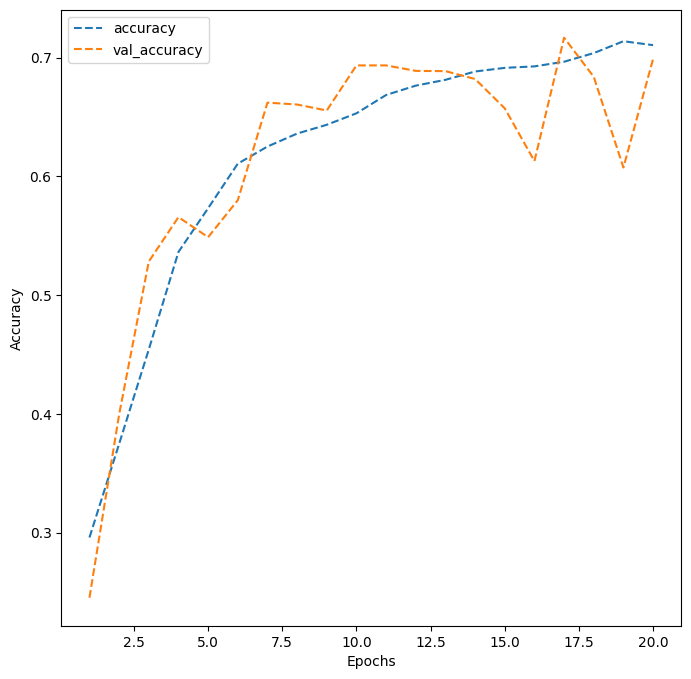

```python
dict_hist = custom_history.history

list_ep = [i for i in range(1, 21)]
plt.figure(figsize = (8, 8))
plt.plot(list_ep, dict_hist['accuracy'], ls = '--', label = 'accuracy')
plt.plot(list_ep, dict_hist['val_accuracy'], ls = '--', label = 'val_accuracy')
plt.ylabel('Accuracy')
plt.xlabel('Epochs')
plt.legend()
plt.show()
```

```python
# Checking out the prediction on the test set
# Predict on the entire test set, specifying steps to cover all samples
test_pred = custom_cnn_model.predict(test_set, steps=len(test_set))

# Get predicted class indices
y_pred = np.argmax(test_pred, axis=1)

# True labels from the generator
y_true = test_set.classes

print(classification_report(y_true, y_pred, target_names=list(test_set.class_indices.keys())))
```

```
4/4 ━━━━━━━━━━━━━━━━━━━━ 1s 24ms/step
              precision    recall  f1-score   support

       happy       0.19      0.16      0.17        32
     neutral       0.17      0.16      0.16        32
         sad       0.28      0.34      0.31        32
    surprise       0.32      0.34      0.33        32

    accuracy                           0.25       128
   macro avg       0.24      0.25      0.24       128
weighted avg       0.24      0.25      0.24       128
```

### **Plotting the Confusion Matrix for the chosen final model**

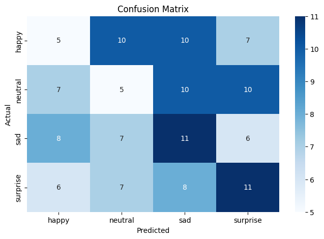

```python
# True labels from the generator
y_true = test_set.classes

# Compute confusion matrix
cm = confusion_matrix(y_true, y_pred)

# Plot confusion matrix
plt.figure(figsize=(8, 5))
sns.heatmap(cm, annot=True, fmt='.0f', cmap='Blues',
            xticklabels=list(test_set.class_indices.keys()),
            yticklabels=list(test_set.class_indices.keys()))
plt.ylabel('Actual')
plt.xlabel('Predicted')
plt.title('Confusion Matrix')
plt.show()
```

**Observations and Insights: Worse than a simpler cnn model **

### **Refined insights**:

- What are the most meaningful insights from the data relevant to the problem?
- Classification of facial expressions is a problem which can be better solved using simpler CNN designs.
- The input components are key to the problem, as such, we must use their initial features to the fullest extent. In this case BNW images as input we must generate the data in greyscales.
- It is a complex problem, because facial expressions vary widely between human beings, from skin color to the shape of the mouth and teeth, as well as setting. Adding further images to the sets in more and more cases could help the model.

### **Proposal for the final solution design**:

- What model do you propose to be adopted? Why is this the best solution to adopt?
- A two way strategy:
  - Build a CNN model simmilar to the best performing CNN built here, while adding and testing more for the hyperparameters.
  - Refine the architecture of the Efficient Net architecture adding dropout layers on top of it.
  - Try for higher resolutions in both cases.